# STAT-401 Group Project

Chao-Wei Tu, Eugene Domrachev, Sean Kirker, Bintou Sako, Anna Tufail, Kyle Weston

```r
library(ggplot2)
library(data.table)
library(ggplot2)
library(gganimate)
library(transformr)
library(dplyr)
library(tidyverse)
library(scales)

#Cases from JLU
confirmed_cases_US <- "https://github.com/CSSEGISandData/COVID-19/raw/master/csse_covid_19_data/csse_covid_19_time_series/time_series_covid19_confirmed_US.csv"
confirmed_cases_US <- read.csv(confirmed_cases_US)
#Deaths from JLU
deaths_US <- "https://raw.githubusercontent.com/CSSEGISandData/COVID-19/master/csse_covid_19_data/csse_covid_19_time_series/time_series_covid19_deaths_US.csv"
deaths_US <- read.csv(deaths_US)

#not updated 4-16
#owid_vaccines <- "https://raw.githubusercontent.com/owid/covid-19-data/13ee5b4126177156fba70fada48f7905da60e9c4/public/data/vaccinations/us_state_vaccinations.csv"

owid_vaccines <- "https://raw.githubusercontent.com/owid/covid-19-data/master/public/data/vaccinations/us_state_vaccinations.csv"

owid_vaccines <- read.csv(owid_vaccines)
```

```r
vaccines_time = owid_vaccines %>% select("date"| "location" | "people_vaccinated")
head(vaccines_time)
```

|  | date | location | people_vaccinated |
| --- | --- | --- | --- |
| 1 | 2021-01-12 | Alabama | 70861 |
| 2 | 2021-01-13 | Alabama | 74792 |
| 3 | 2021-01-14 | Alabama | 80480 |
| 4 | 2021-01-15 | Alabama | 86956 |
| 5 | 2021-01-16 | Alabama | NA |
| 6 | 2021-01-17 | Alabama | NA |

```r
cases = confirmed_cases_US %>% select("Province_State" | starts_with("X"))
deaths = deaths_US %>% select("Province_State" | starts_with("X"))


cases = cases %>% group_by(Province_State) %>% summarise(across(starts_with("X"), sum))
deaths = deaths %>% group_by(Province_State) %>% summarise(across(starts_with("X"), sum))
setDT(cases)
cases = cases %>% melt(cases, id=c("Province_State"), measure=patterns("^X"), value.name="Cases", variable.name="Date")

setDT(deaths)
deaths = deaths %>% melt(deaths, id=c("Province_State"), measure=patterns("^X"), value.name="Deaths", variable.name="Date")

deaths
```

| Province_State | Date | Deaths |
| --- | --- | --- |
| Alabama | X1.22.20 | 0 |
| Alaska | X1.22.20 | 0 |
| American Samoa | X1.22.20 | 0 |
| Arizona | X1.22.20 | 0 |
| Arkansas | X1.22.20 | 0 |
| California | X1.22.20 | 0 |
| Colorado | X1.22.20 | 0 |
| Connecticut | X1.22.20 | 0 |
| Delaware | X1.22.20 | 0 |
| Diamond Princess | X1.22.20 | 0 |

[output cut: 990 more lines]

```r
cases$Date = as.Date(cases$Date, format="X%m.%d.%y")
deaths$Date = as.Date(deaths$Date, format="X%m.%d.%y")
covid <- merge(cases, deaths, by=c("Province_State", "Date"))

state = "Maryland"
state_covid = covid %>% filter(Province_State == state)

#reshape data from 'wide' to 'long' for princess ggplot
state_covid = state_covid %>% pivot_longer(cols= c(Deaths, Cases), names_to = "Type")
#head(state_covid)

vaccines_time$date = as.Date(vaccines_time$date)
state_vax = vaccines_time %>% filter(location == state)
#head(state_vax)
```

[output not shown]

[output cut: 46 more lines]

[output not shown]

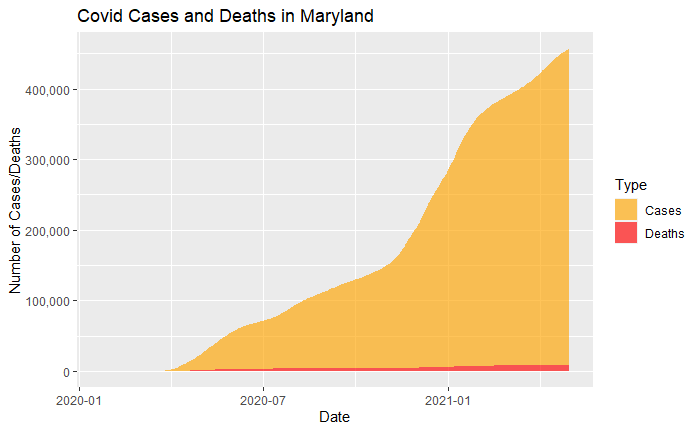

```r
theme_set(theme_gray())



death_plot <- ggplot(data = state_covid, aes(x = Date,y = value , fill = Type)) +
  labs(title = "Covid Cases and Deaths in Maryland"  ) +
  geom_area(alpha = .65)  +
  scale_y_continuous(name = "Number of Cases/Deaths", labels = comma) +
  scale_fill_manual(values = c('orange','red'))
death_plot
death_plot + transition_reveal(Date)
```

```
Removed 4 rows containing missing values (position_stack).
```

[output not shown]

[output cut: 46 more lines]

[output not shown]

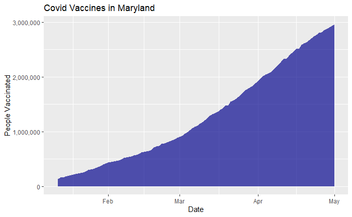

```r
vax_plot <- ggplot(data = state_vax, aes(x = date, y = people_vaccinated)) +
  labs(title = "Covid Vaccines in Maryland"  ) +
    geom_area( fill="darkblue", alpha = 0.67) +
    scale_y_continuous(name = "People Vaccinated", labels = comma) +
    scale_x_date(name = "Date")

vax_plot
vax_plot + transition_reveal(date)
```

```r
#Let's do a hypothesis test of a population proportion:
#First get the data from the latest day as of (4-16)
proportion_deaths <- state_covid[[901,4]]
proportion_cases <- state_covid[[902,4]]
proportion_deaths
```

```
[1] 8528
```

```r
proportion_cases
```

```
[1] 433359
```

```r
#calculate the Z-stat
calc_z_stat <- function(p_hat, p_0, n){
  return((p_hat-p_0)/sqrt(((p_0*(1-p_0))/n)))
}

# Note that we assume deaths are of the proportion of those already confirmed to have covid
p_hat = proportion_deaths/proportion_cases
p_hat #This is an unbiased estimator for the proportion of deaths
```

```
[1] 0.01967883
```

```r
z_stat <- calc_z_stat(p_hat, 0.01, proportion_cases)
z_stat
```

```
[1] 64.03676
```

```r
2*(pnorm(abs(z_stat), lower.tail = FALSE))
```

```
[1] 0
```

However, we reject the null hypothesis a little too conclusively. Lets find a suitable sample size for $a = 0.01$ and $b = 0.05$ with $p' = 0.019$ (close to the $\hat{p}$ we calculated earlier)

```r
calc_samp_size <- function(alpha, p_0, beta, p_prime) {
  z_a <- qnorm(alpha, lower.tail = FALSE)
  z_b <- qnorm(beta, lower.tail = FALSE)
  return(( (z_a*sqrt(p_0*(1-p_0)) + z_b*sqrt(p_prime*(1-p_prime)))/(p_prime - p_0))^2 )
}

n <- ceiling(calc_samp_size(0.01, 0.01, 0.05, 0.019))
n
```

```
[1] 2568
```

So we need a sample size of 2568. Assuming that covid deaths are contained within cases, lets sample from our current sample at the appropriate sample size.

```r
#make a vector to sample from
#433359 - 8528 = 424831
x <- c(replicate(424831,0),replicate(8528,1))

mean(x) #matches p_hat
```

```
[1] 0.01967883
```

```r
#sample the sample
set.seed(0)
samp <- sample(x,n)
mean(samp)
```

```
[1] 0.02141745
```

```r
#calc z test (again) this time with an upper tailed test
z_stat <- calc_z_stat(mean(samp), 0.01, n)
z_stat
```

```
[1] 5.814988
```

```r
pnorm(z_stat, lower.tail = FALSE)
```

```
[1] 3.031903e-09
```

Once again we reject the null hypothesis.

Lets try another approach. How about using data from different slices in time of the pandemic?

```r
proportion_deaths <- c()
proportion_cases <- c()
dates <- c()

for(i in seq(from=100, to= 200, by = 10)){
proportion_cases <- c(proportion_cases, state_covid[[i,4]])
dates <- c(dates, state_covid[[i,2]])
}

for(i in seq(from=101, to= 201, by = 10)){
proportion_deaths <- c(proportion_deaths, state_covid[[i,4]])
}

proportion_deaths
```

```
 [1]    0    0    3    5   31   91  206  319  652  910 1080
```

```r
proportion_cases
```

```
 [1]     9    42   193   583  1660  3617  6968 10032 13684 17766 21742
```

```r
#Now lets automate the process!

for(i in cases){
p_hat = proportion_deaths/proportion_cases
p_hat #This is an unbiased estimator for the proportion of deaths
z_stat <- calc_z_stat(p_hat, 0.01, proportion_cases)
z_stat
p_vals <- 2*(pnorm(abs(z_stat), lower.tail = FALSE))

}

p_vals
```

```
 [1]  7.630246e-01  5.148277e-01  4.388817e-01  7.297316e-01  3.821023e-04  5.058580e-20  1.543906e-60 1.008231e-106  0.000000e+00  0.000000e+00  0.000000e+00
```

```r
#alpha = 0.05
result <- p_vals < 0.05

#Note that TRUE means we reject the NULL hypothesis and FALSE means otherwise
result
```

```
 [1] FALSE FALSE FALSE FALSE  TRUE  TRUE  TRUE  TRUE  TRUE  TRUE  TRUE
```

```r
summary <- data.frame( "Deaths" = proportion_deaths, "Cases" = proportion_cases, "P-Values" = p_vals, "Reject or Fail to Reject?" = result, "Date"= as.Date(dates, origin="1970-01-01"))
view(summary)
```

Notice that earlier in the pandemic our sample is particularly small and we always fail to reject the null hypothesis. However we soon begin rejecting it with every sample. As we know the spread of cases is not linear in nature but, exponential. This leaves a small window where sample sizes are not either too small or too large for our purposes. Lets examine this window further.

```r
proportion_deaths <- c()
proportion_cases <- c()
dates <- c()

for(i in seq(from=134, to= 142, by = 2)){
proportion_cases <- c(proportion_cases, state_covid[[i,4]])
dates <- c(dates, state_covid[[i,2]])
}

for(i in seq(from=135, to= 143, by = 2)){
proportion_deaths <- c(proportion_deaths, state_covid[[i,4]])
}





for(i in cases){
p_hat = proportion_deaths/proportion_cases
p_hat #This is an unbiased estimator for the proportion of deaths
z_stat <- calc_z_stat(p_hat, 0.01, proportion_cases)
z_stat
p_vals <- 2*(pnorm(abs(z_stat), lower.tail = FALSE))

}

p_vals
```

```
[1] 0.9872895022 0.4561358768 0.3008003128 0.0003821023 0.0002726831
```

```r
#alpha = 0.05
result <- p_vals < 0.05

#Note that TRUE means we reject the NULL hypothesis and FALSE means otherwise
result
```

```
[1] FALSE FALSE FALSE  TRUE  TRUE
```

```r
summary2 <- data.frame( "Deaths" = proportion_deaths, "Cases" = proportion_cases, "P-Values" = p_vals, "Reject or Fail to Reject?" = result, "Date"= as.Date(dates, origin="1970-01-01"))
view(summary2)

#once we pass 31 deaths and 1660 cases, we begin to exclusively reject the null hypothesis
```

In conclusion, while hypothesis testing is a powerful procedure, it has its limitations. This exercise shows the limits of using a hypothesis test when one cannot control size and, more importantly, procedures for collecting data. What the hypothesis test tells us has little significance as whether we reject or fail to reject is atlmost entirely dependent on the size of our sample.

# Hypothesis on Linear Regression Between Vaccinces and Deaths

We are interested in seeing if there is a negative relationship between the number of vaccinated people versus the number of death.

Here are some functions that might be helpful for the linear regressions later.

```r
sxx <- function(x){
  x_bar = mean(x)
  return(Reduce('+', (lapply(x, function(e)(e - x_bar)^2))))
}
syy <- function(y){
  y_bar = mean(y)
  return(Reduce('+', (lapply(y, function(e)(e - y_bar)^2))))
}
sxy <- function(x, y){
  x = as.numeric(x)
  x_bar = mean(x)
  y_bar = mean(y)

  s = 0
  for(i in 1:length(x)){
    s = s + (x[i] - x_bar)*(y[i] - y_bar)
  }
  return(s)
}
```

Unfortunately, there is some missing data for the number of doses administered to people in some days. We will first find a linear model of the number of vaccine administered as a function of time, then we use this model to fill in the missing data.

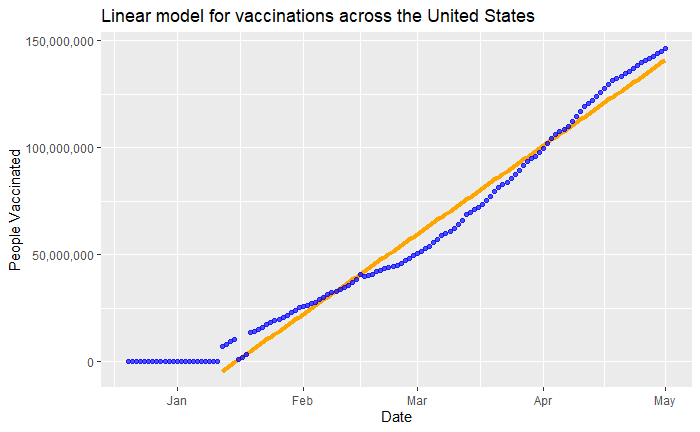

```r
# we omit rows that has NA and use the rest to find our linear model
tt_vac <- na.omit(vaccines_time %>% filter(location == "United States"))

x_samp = as.numeric(tt_vac$date)
y_samp = tt_vac$people_vaccinated
x_bar = mean(x_samp)
y_bar = mean(y_samp)

# using the functions earlier, we can find an estimate of the parameters of the linear model
beta_hat <- sxy(x_samp, y_samp)/sxx(x_samp)
alpha_hat <- y_bar - beta_hat * x_bar
y_hat <- function(x){beta_hat*x + alpha_hat}
# we then find the day that has the missing data, use the model to predict how many doses were administered that day. Put zero if the predicted model gives a negative value.

tt_vac <- vaccines_time %>% filter(location == "United States")
x <- as.numeric(tt_vac$date)
y <-tt_vac$people_vaccinated
for(i in 1:length(x)){
  if(is.na(y[i])){
    y[i] <- if(y_hat(x[i]) > 0) y_hat(x[i]) else 0
  }
}
tt_vac$people_vaccinated <- y


# plot(x_samp, y_hat(x_samp), type='l', main = "United States", xlab = "date", ylab = "people vaccinated", xaxt='n',xlim = c(min(x),max(x)), ylim = c(min(y),max(y)))
# axis(1, at=x[seq(1, length(x), by=length(x)/6)], labels=tt_vac$date[seq(1, length(x), by=length(x)/6)])
# points(x, y)



y_hat <- y_hat(x_samp)
x_samp <- as.Date(x_samp, origin="1970-01-01")
x <- as.Date(x, origin="1970-01-01")


ggplot(data =NULL , aes(x_samp, y_hat)) +
         geom_line(color = "orange", size = 1.6) +
         geom_point(alpha = 0.67, color="blue", aes(as.Date(x, origin="1970-01-01"),y)) +
         labs(title = "Linear model for vaccinations across the United States" ) +
         scale_y_continuous(name = "People Vaccinated", labels = comma) +
         scale_x_date( name = "Date")
```

```r
NA
NA
NA
```

From the plot, we can see that the model seems to overestimated some data and underestimated others. This tells us that fitting a linear regression may not be the best way to estimate the true value of the missing data. However, our main goal is to find a reasonable way to fill in the missing data, so we can use all of data points as our input variables. Approximate the missing data with a linear model is good enough for the work we are doing.

Now we have taken care of the missing data, we can start to answer the question that we are interested: Is there any negative relationship between the number of vaccines administered and the number of deaths from COVID? It might be more reasonable to look at new deaths everyday instead of cumulative deaths.

First we want to create a new data frame that records new deaths from the deaths data.

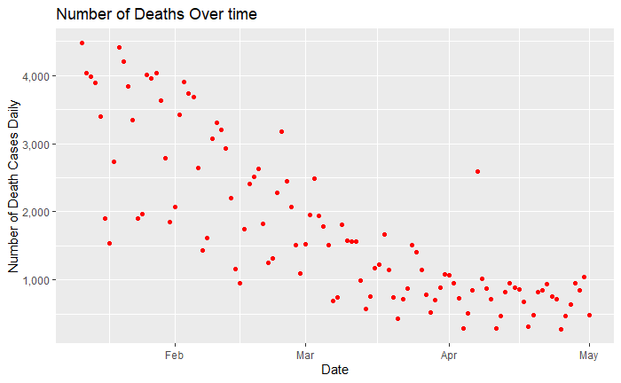

```r
date_deaths <- aggregate(deaths$Deaths, by=list(Category=deaths$Date), FUN=sum)
date_deaths$new_death <- diff(c(0, as.matrix(date_deaths$x)))
colnames(date_deaths) <- c("date", "total_deaths", "daily_deaths")
# we only consider dates after 2021-01-12 because that's when we started to have data about the number of vaccinated people
date_deaths <- date_deaths %>% filter(date >= "2021-01-12")

#plot(date_deaths$date, date_deaths$daily_deaths, xlab="number of people vacinated", ylab = "number of death cases daily")

# NOTE: I believe this actually deaths over time

ggplot(data = date_deaths ) +
  geom_point(aes(date, daily_deaths), color = "red") +
  labs(title = "Number of Deaths Over time" ) +
         scale_y_continuous(name = "Number of Death Cases Daily", labels = comma) +
         scale_x_date( name = "Date")
```

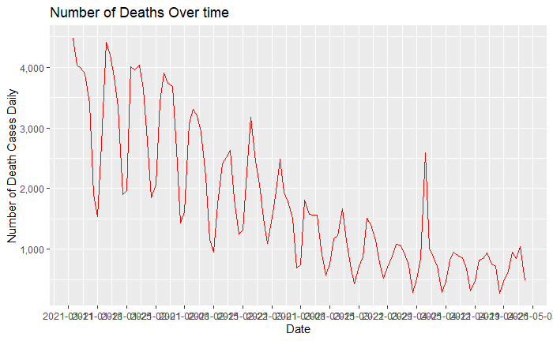

```r
#Now, lets look at this in line form!
ggplot(data = date_deaths ) +
  geom_line(aes(date, daily_deaths), color = "red") +
  labs(title = "Number of Deaths Over time" ) +
         scale_y_continuous(name = "Number of Death Cases Daily", labels = comma) +
         scale_x_date( name = "Date", date_breaks = "1 week")
```

```r
#Notice that when we place the breaks on this graph at the week interval, our breaks correspond with those low points!
#I believe this is due to the aggregate nature of this data. Most states/institutions seem to report their numbers
#on Wednesdays and are on breaks during weekends which is why we see this pattern!
```

Lets get rid of columns we don’t need.

```r
vac_death <- merge(tt_vac[ , c("date", "people_vaccinated")], date_deaths[ , c("date", "daily_deaths")], by="date")
```

We can now start our hypothesis test. Recall that we want to know if there is a negative relationship between the number of people get vaccinated and number of daily deaths. We set our null hypothesis to there is no relationship between the two features and alternative hypothesis to there is a negative relationship between the two features. In other words, we can write them as $H_0:\hat{\beta}=0$ and $H_a:\hat{\beta}<0$ with $\hat{\beta}$ as our estimator for true slope for the two parameters that we are interested.

```r
beta = 0
x_samp = vac_death$people_vaccinated
y_samp = vac_death$daily_deaths
n = length(vac_death$people_vaccinated)
x_bar = mean(x_samp)
y_bar = mean(y_samp)


# using the functions earlier, we can find an estimate of the parameters of the linear model
beta_hat <- sxy(x_samp, y_samp)/sxx(x_samp)
alpha_hat <- y_bar - beta_hat * x_bar
y_hat <- function(x){beta_hat*x + alpha_hat}


#model utility test
sse = syy(y_samp) - beta_hat*sxy(x_samp, y_samp)
s_squared = sse/(n-2)
t_stat = (beta_hat )/sqrt(s_squared/sxx(x_samp))
p_val = 2*pt(abs(t_stat), n-2, lower.tail = FALSE)
p_val
```

```
[1] 1.956865e-23
```

```r
#we conclusively  reject, meaning the linear model may be usable!
```

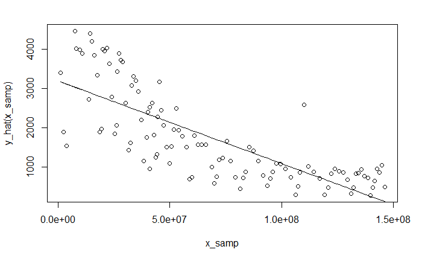

```r
#plot
plot(x_samp, y_hat(x_samp), type='l', xlim = c(min(x_samp),max(x_samp)), ylim = c(min(y_samp),max(y_samp)))
points(x_samp, y_samp)
```

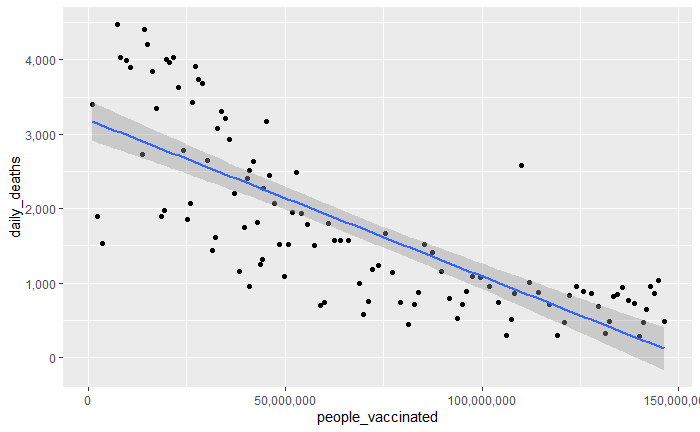

```r
#Using ggplot to calculate the linear regression line with each as a control and  response variable
ggplot(data =vac_death, aes(people_vaccinated, daily_deaths)) + geom_point() + scale_y_continuous( labels = comma) +  geom_smooth(method='lm')+ scale_x_continuous( labels = comma)
```

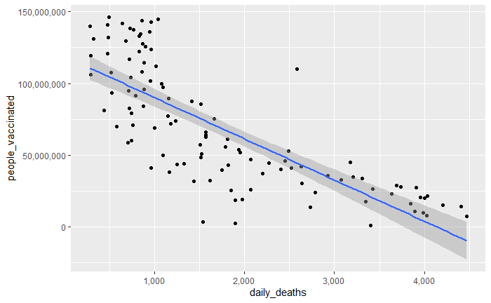

```r
ggplot(data =vac_death, aes(daily_deaths, people_vaccinated)) + geom_point() + scale_y_continuous( labels = comma) +  geom_smooth(method='lm')+
  scale_x_continuous( labels = comma)
```

```r
#using lm find a_hat and b_hat
lm(vac_death$daily_death ~ vac_death$people_vaccinated)
```

```
Call:
lm(formula = vac_death$daily_death ~ vac_death$people_vaccinated)

Coefficients:
                (Intercept)  vac_death$people_vaccinated
                  3.192e+03                   -2.102e-05
```

```r
lm(vac_death$people_vaccinated ~ vac_death$daily_death)
```

```
Call:
lm(formula = vac_death$people_vaccinated ~ vac_death$daily_death)

Coefficients:
          (Intercept)  vac_death$daily_death
            118737292                 -28717
```

Know we can find the t statistics and p value with the information we have.

```r
sse = syy(y_samp) - beta_hat*sxy(x_samp, y_samp)
s_squared = sse/(n-2)
t_stat = (beta_hat - beta)/sqrt(s_squared/sxx(x_samp))
p_val = pt(t_stat, n-2, lower.tail = TRUE)
p_val
```

```
[1] 9.784327e-24
```

We get a p value that is so small that any reasonable significance level is greater than it, so we can easily conclude that we reject our null hypothesis and say that number of people vaccinated has a negative relationship with daily death cases.

Here is the slope of the linear model.

```r
beta_hat
```

```
[1] -2.101847e-05
```

```r
1/beta_hat
```

```
[1] -47577.2
```

[output not shown]